# GIT

Hit the `git` tab and check the box next to this markdown Rmd. Hit `commit` to show the commit window.

[figure not shown]

Here we will describe the commit so we can remember what we were doing at this point in time. After the commit, you can close the windows.

[figure not shown]

Now we will change the code in some way, and record the new version of the document. Let’s add the code for reading in the boulder data and save the new version. Repeat the commit process by clicking the checkmark next to the file you working on and hitting commit. Give this newer version of the code a new description. Notice that the new line of code is in green indicating that this has not been committed. After the commit, you can close the windows.

[figure not shown]

```r
boulder <- st_read("C:/Users/dbvanber/Box/Labs/Adv_Week_1/Locationdata.shp")
ggplot() +
    geom_sf(data =boulder, aes(color=PT_Elev),
    fill = NA, alpha = .2) +
  scale_colour_gradientn(colours = terrain.colors(10)) +
  theme_bw()
```

Let’s deomstrate how we can revert to an older version of the code. To do this, hit the `Diff` button and navigate to the `History` tab. The SHA code identifies the different versions that you have committed. Choose the SHA code that you want revert to and copy it.

[figure not shown]

To actually do the reset we will be using the terminal window in R Studio. If this is not already a window tab, activate it using `Tools > Terminal > New Terminal`. We will reset the older version by typing `git reset --hard [your SHA]` in the terminal(use the right button on your mouse to paste the SHA). You will need to use the SHA code specific to your version for the reset. This will reset to an older version. Remember that a hard reset will revert to that stage, meaning that previous stage version will be lost.

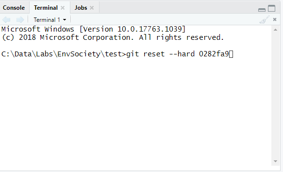